# ligand_receptor_scatterplot

Hani Jieun Kim

11/03/2020

# 1 Ligand and receptor scatterplot

The script reproduces the scatter plot in Figure 5d. It is shown in Figure 1.

Load expression matrices

```r
#read in log-transformed RNA expression matrix
rna_log_norm <- readRDS("lr_interaction_rna_log_norm.rds")
head(rna_log_norm[1:10,1:10])
```

```
##            [,1] [,2] [,3]      [,4] [,5] [,6] [,7] [,8] [,9] [,10]
## AL627309.1    0    0    0 0.0000000    0    0    0    0    0     0
## AL669831.5    0    0    0 0.0000000    0    0    0    0    0     0
## FAM87B        0    0    0 0.0000000    0    0    0    0    0     0
## LINC00115     0    0    0 0.0000000    0    0    0    0    0     0
## FAM41C        0    0    0 0.0000000    0    0    0    0    0     0
## NOC2L         0    0    0 0.3577558    0    0    0    0    0     0
```

```r
#read in log-transformed and normalised ADT count matrix
adt_log_norm <- readRDS("lr_interaction_adt_log_norm.rds")
head(adt_log_norm[1:10,1:10])
```

```
##               AAACCTGAGACAAAGG AAACCTGAGCTACCGC AAACCTGCACCAGGTC
## B220 (CD45R)                 0                0                0
## B7-H1 (PD-L1)                0                0                0
## C-kit (CD117)                0                0                0
## CCR7                         0                0                0
## CD11b                        0                0                0
## CD11c                        0                0                0
##               AAACCTGCACTCTGTC AAACCTGGTATGAAAC AAACCTGGTGAGTATA
## B220 (CD45R)                 0                0                0
## B7-H1 (PD-L1)                0                0                0
## C-kit (CD117)                0                0                0
## CCR7                         0                0                0
## CD11b                        0                0                0
## CD11c                        0                0                0
##               AAACGGGAGATAGGAG AAACGGGAGTTACGGG AAACGGGCACCGATAT
## B220 (CD45R)                 0                0                0
## B7-H1 (PD-L1)                0                0                0
## C-kit (CD117)                0                0                0
## CCR7                         0                0                0
## CD11b                        0                0                0
## CD11c                        0                0                0
##               AAACGGGCATAAAGGT
## B220 (CD45R)                 0
## B7-H1 (PD-L1)                0
## C-kit (CD117)                0
## CCR7                         0
## CD11b                        0
## CD11c                        0
```

# 2 Ligand-receptor predictions

Load ligand-receptor pairs identified as significantly interacting by CiteFuse

```r
lr_pairs_CiteFuse <- readRDS("lr_pairs_CiteFuse.rds") # used `se_alt_exp = TRUE` to run `ligandReceptorTest`
lr_pairs_RNA <- readRDS("lr_pairs_RNA.rds") # used `se_alt_exp = FALSE` to run `ligandReceptorTest`
```

Note that for each pair of interactions (cluster A_cluster B), cluster A is enriched by the ligand and cluster B is enriched by the receptor.

```r
head(lr_pairs_CiteFuse)
```

```
## $`1_1`
##  [1] "GZMA_CD2"       "PRF1_CD2"       "CST7_CD2"       "GNLY_CD2"
##  [5] "AOAH_CD11b"     "GZMA_CD11b"     "PRF1_CD11b"     "CCL3_CD11b"
##  [9] "CCL5_CD11b"     "TGFB1_CD11b"    "TNFRSF1B_CD11b" "SPON2_CD11b"
##
## $`2_1`
## [1] "CD40LG_CD11b" "FLT3LG_CD11b" "IL6R_CD11b"   "IL7R_CD11b"   "TIMP1_CD11b"
##
## $`3_1`
##  [1] "CD8A_CD2"       "CCL5_CD2"       "AOAH_CD11b"     "CD8A_CD11b"
##  [5] "CD8B_CD11b"     "GZMA_CD11b"     "PRF1_CD11b"     "CCL5_CD11b"
##  [9] "TGFB1_CD11b"    "TNFRSF1B_CD11b" "SPON2_CD11b"
##
## $`4_1`
## [1] "CD40_CD11b" "IL4R_CD11b" "LY86_CD11b"
##
## $`5_1`
##  [1] "TNFRSF1B_CD2"   "C1QA_CD11b"     "ICAM4_CD11b"    "LGALS3_CD11b"
##  [5] "LGALS9_CD11b"   "LYZ_CD11b"      "PLAUR_CD11b"    "S100A8_CD11b"
##  [9] "S100A9_CD11b"   "TGFB1_CD11b"    "TGFBI_CD11b"    "TIMP1_CD11b"
## [13] "TNFRSF1B_CD11b" "LY86_CD11b"     "LY96_CD11b"     "IL17RA_CD11b"
##
## $`6_1`
## [1] "CD40_CD11b" "LY86_CD11b" "LY96_CD11b"
```

# 3 Categories of ligand-receptor interactions

Function to substitute gene names with protein names and vice versa

```r
gsub_rna <- function(x) {
  x <- gsub("SELL", "CD62L", x)
  x <- gsub("ITGAM", "CD11b", x)
  x <- gsub("FCGR3A", "CD16", x)
  x <- gsub("FCGR3B", "CD16", x)
  x <- gsub("PTPRC", "CD45", x)
  x <- gsub("DPP4", "CD26 (Adenosine)", x)
  return(x)
}

gsub_rna_backward <- function(x) {
  x <- gsub("CD62L", "SELL", x)
  x <- gsub("CD11b", "ITGAM", x)
  x <- gsub("CD16", "FCGR3B", x)
  x2 <- gsub("FCGR3B", "FCGR3A", x)
  x <- unique(x, x2)
  x <- gsub("CD45", "PTPRC", x)
  x <- gsub("CD26 \\(Adenosine)", "DPP4", x)
  return(x)
}
```

Generate the three categories of ligand-receptor interactions (common, CiteFuse-specific, and RNA-specific)

```r
lr_pairs_RNA_alias <- lapply(lr_pairs_RNA, gsub_rna)

interactions <- lapply(1:length(lr_pairs_RNA_alias), function(x) {
  rna_tmp <- lr_pairs_RNA_alias[[x]]
  adt_tmp <- lr_pairs_CiteFuse[[x]]
  common <- intersect(rna_tmp, adt_tmp)
  adt_specific <- adt_tmp[!adt_tmp %in% common]
  rna_specific <- rna_tmp[!rna_tmp %in% common]

  c(RNA_specific = length(rna_specific), CiteFuse_specific = length(adt_specific), Common = length(common))
})

interactions <- do.call(rbind, interactions)
rownames(interactions) <- names(lr_pairs_CiteFuse)
head(interactions)
```

```
##     RNA_specific CiteFuse_specific Common
## 1_1           24                 0     12
## 2_1           14                 0      5
## 3_1           37                 0     11
## 4_1           13                 0      3
## 5_1           41                 0     16
## 6_1           15                 0      3
```

# 4 Identify receptors by cluster

Identify the receptors involved in a ligand-receptor interaction by cluster

```r
lr_pairs_Receptors <- lapply(1:length(lr_pairs_RNA_alias), function(x) {

  rna_tmp <- lr_pairs_RNA_alias[[x]]
  adt_tmp <- lr_pairs_CiteFuse[[x]]
  common <- intersect(rna_tmp, adt_tmp)
  adt_specific <- adt_tmp[!adt_tmp %in% common]
  rna_specific <- rna_tmp[!rna_tmp %in% common]

  res <- list(common = common, ADT = adt_specific, RNA = rna_specific)
  res <- lapply(res, function(x) {
    unique(sapply(strsplit(x, "_"), "[[", 2))
  })
  return(res)
})

#### extract receptors
names(lr_pairs_Receptors) <- sapply(strsplit(names(lr_pairs_RNA_alias), "_"), "[[", 2)

#### group receptors by cluster
lr_pairs_Receptors_byCluster <- lapply(1:16, function(i) {
  tmp <- lr_pairs_Receptors[names(lr_pairs_Receptors) == i]

  common <- unique(unlist(lapply(tmp, "[[", "common")))
  ADT <- unique(unlist(lapply(tmp, "[[", "ADT")))
  RNA <- unique(unlist(lapply(tmp, "[[", "RNA")))

  res <- list(Common = common, CiteFuse_specific = ADT, RNA_specific = RNA)
  return(res)
})
```

# 5 Calculate ranked expression of receptors by cluster

Load cluster labels from CiteFuse

```r
load("cluster_labels.RData", verbose=T)
```

```
## Loading objects:
##   CiteFuse_cluster_labels
##   ADT_cluster_labels
##   RNA_cluster_labels
```

First calculate average expression of RNA and protein of receptors by cluster

```r
receptor_meanExprs_RNA <- apply(rna_log_norm, 1, function(x) {
  aggregate(x, list(CiteFuse_cluster_labels), mean)$x
})

receptor_meanExprs_ADT <- apply(adt_log_norm, 1, function(x) {
  aggregate(x, list(CiteFuse_cluster_labels), mean)$x
})
```

Second rank the average expression across the clusters

```r
receptor_rankedExprs_RNA  <- apply(receptor_meanExprs_RNA, 2, function(x){
  rank(x, ties.method="random")
})

receptor_rankedExprs_ADT <- apply(receptor_meanExprs_ADT, 2, function(x){
  rank(x, ties.method="random")
})

receptor_rankedExprs_RNA <- t(receptor_rankedExprs_RNA)
receptor_rankedExprs_ADT <- t(receptor_rankedExprs_ADT)

receptor_ranking_RNA <- receptor_ranking_ADT <- list()

for (i in 1:length(lr_pairs_Receptors_byCluster)) {

  Common <- lr_pairs_Receptors_byCluster[[i]]$Common
  CiteFuse_specific <- lr_pairs_Receptors_byCluster[[i]]$CiteFuse_specific
  RNA_specific <- lr_pairs_Receptors_byCluster[[i]]$RNA_specific

  Common.RNA <- receptor_rankedExprs_RNA[gsub_rna_backward(Common), i]
  CiteFuse_specific.RNA <- receptor_rankedExprs_RNA[gsub_rna_backward(CiteFuse_specific), i]
  RNA_specific.RNA <- receptor_rankedExprs_RNA[gsub_rna_backward(RNA_specific), i]

  Common.ADT <- receptor_rankedExprs_ADT[Common, i]
  CiteFuse_specific.ADT <- receptor_rankedExprs_ADT[CiteFuse_specific, i]
  RNA_specific.ADT <- receptor_rankedExprs_ADT[RNA_specific, i]


  receptor_ranking_RNA[[i]] <- list(RNA_specific = RNA_specific.RNA,
                                    CiteFuse_specific = CiteFuse_specific.RNA,
                                    Common = Common.RNA)

  receptor_ranking_ADT[[i]] <- list(RNA_specific = RNA_specific.ADT,
                                    CiteFuse_specific = CiteFuse_specific.ADT,
                                    Common = Common.ADT)
}

RNA_specific.RNA <- unlist(lapply(receptor_ranking_RNA, "[[", "RNA_specific"))
CiteFuse_specific.RNA <- unlist(lapply(receptor_ranking_RNA, "[[", "CiteFuse_specific"))
Common.RNA <- unlist(lapply(receptor_ranking_RNA, "[[", "Common"))

RNA_specific.ADT <- unlist(lapply(receptor_ranking_ADT, "[[", "RNA_specific"))
CiteFuse_specific.ADT <- unlist(lapply(receptor_ranking_ADT, "[[", "CiteFuse_specific"))
Common.ADT <- unlist(lapply(receptor_ranking_ADT, "[[", "Common"))
```

# 6 Plot of relative ranking of RNA versus protein expression of the receptors

Geneate a scatter of RNA and protein expression of receptors ranked across the clusters. Scatter plot is generated for each category of receptors in Figure 1)

```r
pdf(file="Figure5d.pdf", width=12, height=5)
par(mfrow=c(1,3))
plot(RNA_specific.ADT, RNA_specific.RNA,
     col="#B3DE69",
     pch=19,
     xlim=c(1,16), ylim=c(1,16),
     xlab="Relative ranking of protein \nexpression across clusters",
     ylab="Relative ranking of RNA expression across clusters",
     main="RNA-specific")
abline(lm(RNA_specific.RNA~RNA_specific.ADT), col="#B3DE69", lty="dotted", lwd=2)
plot(CiteFuse_specific.ADT, CiteFuse_specific.RNA,
     col="#FDB462",
     pch=19,
     xlim=c(1,16), ylim=c(1,16),
     xlab="Relative ranking of protein \nexpression across clusters",
     ylab="Relative ranking of RNA expression across clusters",
     main="CiteFuse_specific")
abline(lm(CiteFuse_specific.RNA~CiteFuse_specific.ADT), col="#FDB462", lty="dotted", lwd=2)
plot(Common.ADT, Common.RNA,
     col="#FCCDE5",
     pch=19,
     xlab="Relative ranking of protein \nexpression across clusters",
     ylab="Relative ranking of RNA expression across clusters",
     xlim=c(1,16), ylim=c(1,16),
     main="Common")
abline(lm(Common.RNA~Common.ADT), col="#FCCDE5", lty="dotted", lwd=2)
dev.off()
```

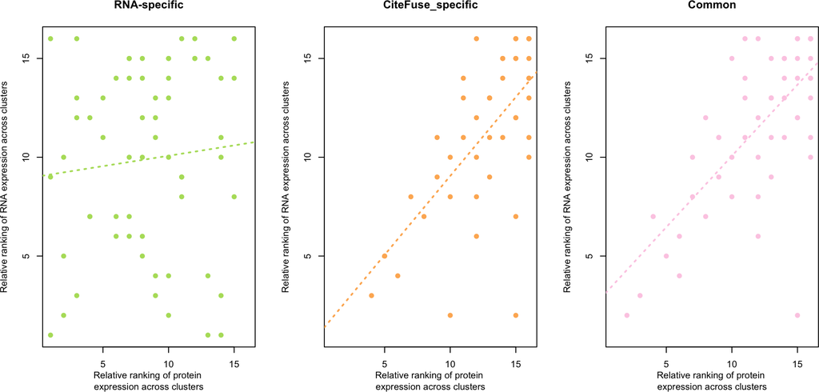

Figure 1: Relative ranking of RNA vs protein expression of receptors across clusters

```r
par(mfrow=c(1,3))
plot(RNA_specific.ADT, RNA_specific.RNA,
     col="#B3DE69",
     pch=19,
     xlim=c(1,16), ylim=c(1,16),
     xlab="Relative ranking of protein \nexpression across clusters",
     ylab="Relative ranking of RNA expression across clusters",
     main="RNA-specific")
abline(lm(RNA_specific.RNA~RNA_specific.ADT), col="#B3DE69", lty="dotted", lwd=2)
plot(CiteFuse_specific.ADT, CiteFuse_specific.RNA,
     col="#FDB462",
     pch=19,
     xlim=c(1,16), ylim=c(1,16),
     xlab="Relative ranking of protein \nexpression across clusters",
     ylab="Relative ranking of RNA expression across clusters",
     main="CiteFuse_specific")
abline(lm(CiteFuse_specific.RNA~CiteFuse_specific.ADT), col="#FDB462", lty="dotted", lwd=2)
plot(Common.ADT, Common.RNA,
     col="#FCCDE5",
     pch=19,
     xlab="Relative ranking of protein \nexpression across clusters",
     ylab="Relative ranking of RNA expression across clusters",
     xlim=c(1,16), ylim=c(1,16),
     main="Common")
abline(lm(Common.RNA~Common.ADT), col="#FCCDE5", lty="dotted", lwd=2)
```

Assess correlation between RNA and protein expression of receptors by cateory

```r
cor.test(RNA_specific.ADT, RNA_specific.RNA)
```

```
##
##  Pearson's product-moment correlation
##
## data:  RNA_specific.ADT and RNA_specific.RNA
## t = 0.68723, df = 58, p-value = 0.4947
## alternative hypothesis: true correlation is not equal to 0
## 95 percent confidence interval:
##  -0.1678832  0.3361268
## sample estimates:
##        cor
## 0.08987279
```

```r
cor.test(CiteFuse_specific.ADT, CiteFuse_specific.RNA)
```

```
##
##  Pearson's product-moment correlation
##
## data:  CiteFuse_specific.ADT and CiteFuse_specific.RNA
## t = 5.7569, df = 43, p-value = 8.246e-07
## alternative hypothesis: true correlation is not equal to 0
## 95 percent confidence interval:
##  0.4541614 0.7986193
## sample estimates:
##       cor
## 0.6597437
```

```r
cor.test(Common.ADT, Common.RNA)
```

```
##
##  Pearson's product-moment correlation
##
## data:  Common.ADT and Common.RNA
## t = 6.9693, df = 52, p-value = 5.538e-09
## alternative hypothesis: true correlation is not equal to 0
## 95 percent confidence interval:
##  0.5248544 0.8116741
## sample estimates:
##     cor
## 0.69495
```